# The Effect of in-school and out-school life on student score and grade and their charactristics.

## by Marawan Abdelrahman

## Investigation Overview

> In this Invistagtion, I wanted to know the effect of student's life in school and outside school and determine their effect on student's score and grade compared to other students in thesame country.

## Dataset Overview

> This Dataset contains a survey of students' skills at the end of compulasory(obligatory) education in 68 different location around the world and describes how well are the student beyond this education. This aslo contains the scores of 485490 student who conducted PISA 2012 assesment in science, math and reading.

## Distribution of the time consumed by students to learn math and science

> In this Visualization we can see that that the range of time students consume to learn math and science ranges between 100 and 500 minutes per week (1:40 to 8:20 hours) and there is concentration around 200 minutes (3:20 hour). We can see that students take less time to learn math than science.

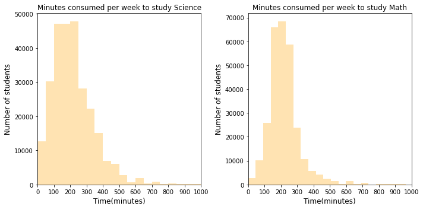

```python
# Two subplots on the right is minutes consumed weekly for learning math and on the left for science
dfsm = df2[["SMINS","MMINS"]]

plt.figure(figsize=(10,5))


plt.subplot(1,2,1)

bins_smin = np.arange(0, dfsm["SMINS"].max()+50,50 )
tickss = np.arange(0, dfsm["SMINS"].max()+100,100 )
plt.hist(dfsm["SMINS"], bins = bins_smin,color="orange",alpha = 0.3)
plt.xticks(tickss,tickss.astype("int"))
plt.xlim((0,1000))
plt.title("Minutes consumed per week to study Science")
plt.xlabel("Time(minutes)",fontsize = 12)
plt.ylabel("Number of students",fontsize = 12)

plt.subplot(1,2,2)
tickss2 = np.arange(0, dfsm["MMINS"].max()+100,100 )
bins_mmin = np.arange(0, dfsm["MMINS"].max()+46,46 )
plt.hist(dfsm["MMINS"], bins = bins_mmin,color="orange",alpha = 0.3)
plt.xticks(tickss2,tickss2.astype("int"))
plt.xlim((0,1000))
plt.title("Minutes consumed per week to study Math")
plt.xlabel("Time(minutes)",fontsize = 12)
plt.ylabel("Number of students",fontsize = 12)

plt.tight_layout()
```

## Minutes consumed to learn in math and Science vs Math and Science PISA score

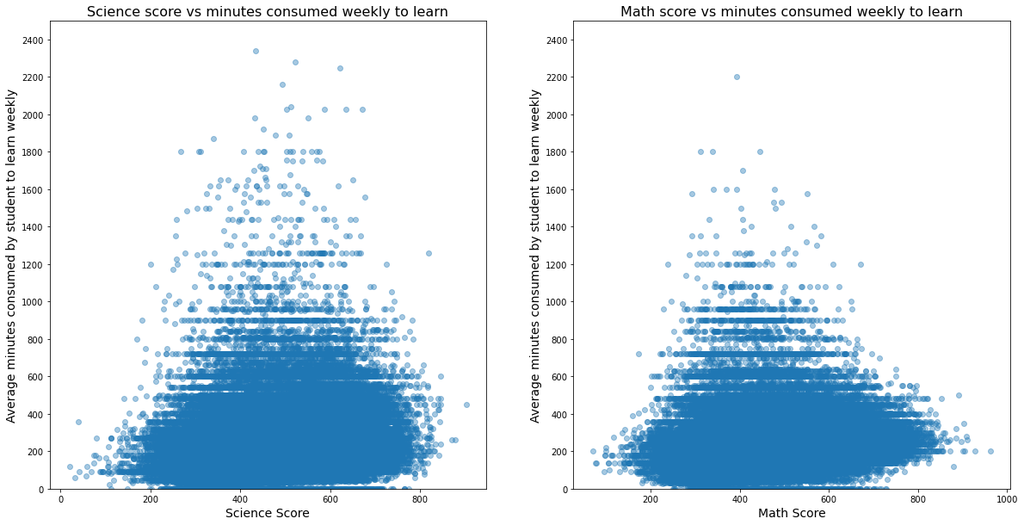

```python
# Comparing science and math scores vs minutes per week that is consumed on learning them.
plt.figure(figsize=(20,10))
dfsm2 = df2[["SMINS","MMINS","PV1SCIE","PV1MATH"]].dropna()
tickss3 = np.arange(0, dfsm["SMINS"].max()+200,200 )

# Science score vs minutes consumed weekly to learn
plt.subplot(1,2,1)
sb.regplot(data = dfsm2, y= "SMINS",x = "PV1SCIE",fit_reg=0,scatter_kws={"alpha":0.4})
plt.yticks(tickss3,tickss3.astype("int"))
plt.ylabel("Average minutes consumed by student to learn weekly",fontsize = 14)
plt.xlabel("Science Score",fontsize = 14)
plt.ylim((0,2500))
plt.title("Science score vs minutes consumed weekly to learn",fontsize = 16)
# Math score vs minutes consumed weekly to learn
plt.subplot(1,2,2)
sb.regplot(data = dfsm2, y= "MMINS",x = "PV1MATH",fit_reg=0,scatter_kws={"alpha":0.4})
plt.yticks(tickss3,tickss3.astype("int"))
plt.ylabel("Average minutes consumed by student to learn weekly",fontsize = 14)
plt.xlabel("Math Score",fontsize = 14)
plt.ylim((0,2500))
plt.title("Math score vs minutes consumed weekly to learn",fontsize = 16)
```

## Quick Learner vs Total score in Math, Reading and Science

> This is a comparison between Students' opinion to their degree of agreement that they are quick learners. This plots shows us that students with total scoremost likely agree that they are quick learners.

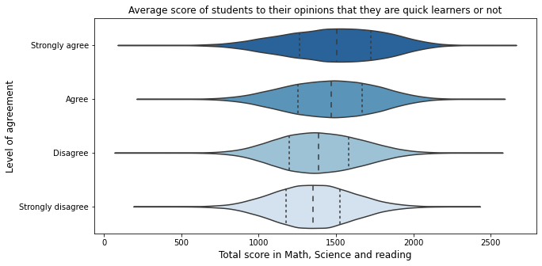

```python
df2['QUICK_LEARNER']=df2['QUICK_LEARNER'].astype(CategoricalDtype(categories=['Strongly agree','Agree','Disagree','Strongly disagree']))
df2["SUM_SUB"] = df2["PV1MATH"] + df2["PV1SCIE"] + df2["PV1READ"] # Sum the scores of three subjects
comparison = df2[["QUICK_LEARNER","SUM_SUB"]].dropna()
plt.figure(figsize=(10,5))
sb.violinplot(data = comparison, x = "SUM_SUB",y = "QUICK_LEARNER",palette="Blues_r",inner="quartile")
plt.ylabel("Level of agreement",fontsize = 12)
plt.xlabel("Total score in Math, Science and reading",fontsize = 12)
plt.title("Average score of students to their opinions that they are quick learners or not")
```

## Math score vs time consumed on learning math to the degree of student need of help from the teacher.

> This plots shows that the amount of time needed yo study math decreases as the help need of help decrease and the score range shrinks when the student need less help(from 100 to 900 for Every lesson help and shrinks to (200 to 800 for rarely help from teacher). We can see the outliers decreases too.

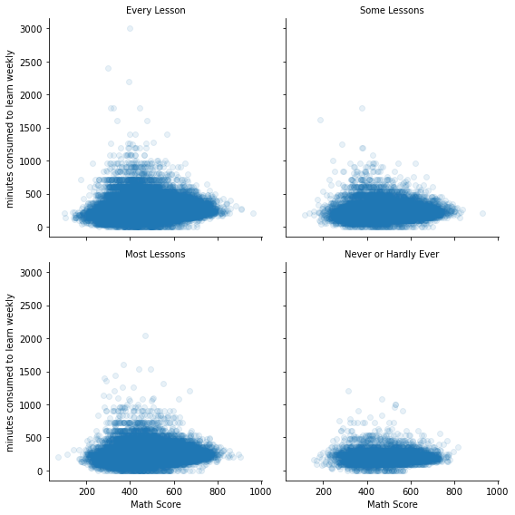

```python
# Math score vs minutes consumed for learning weekly vs the need of teacher help
hellp = df2[["MTEACHER_HELP","MMINS","PV1MATH"]].dropna()
g = sb.FacetGrid(data= hellp, col = "MTEACHER_HELP",col_wrap=2,size=4);
g = g.map(sb.regplot,"PV1MATH","MMINS", fit_reg=False,scatter_kws={'alpha':0.1});

g.set_titles(col_template = '{col_name}')
g.axes[2].set_xlabel("Math Score")
g.axes[3].set_xlabel("Math Score")
g.axes[0].set_ylabel("minutes consumed to learn weekly")
g.axes[2].set_ylabel("minutes consumed to learn weekly")
plt.tight_layout()
```

## Country vs Average total Score in math, science and reading

> Most of top 10 countries scores aresimilar to each other they all range from 1750 to 1500, China-shinghai is the top. This conclusion needs further analysis to determine the reasons.

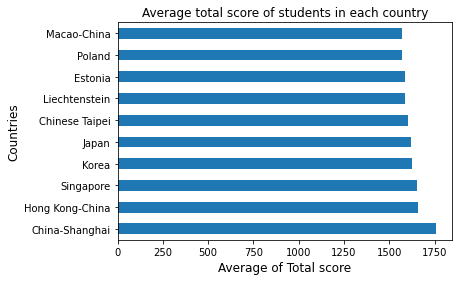

```python
plt.figure(figsize=(20,10))
df2_gb["SUM"] = df2_gb["READ"]+df2_gb["MATH"]+df2_gb["SCIE"]
top = df2_gb[["SUM","MATH","READ","SCIE"]].sort_values(by="SUM",ascending = False).head(10)
top[["SUM"]].plot(kind= "barh",legend = 0).set_xlabel("SUM SCORES")
plt.ylabel("Countries",fontsize = 12)
plt.xlabel("Average of Total score",fontsize = 12)
plt.title("Average total score of students in each country")
```

## Mother at home vs total student score by the country.

> In this one It shows that the student who doesn't have mother at home they got less in total score compared to Srudents who have mothers at home. Estonia have few outliers that the some students without mother at home exceeded the one who have.

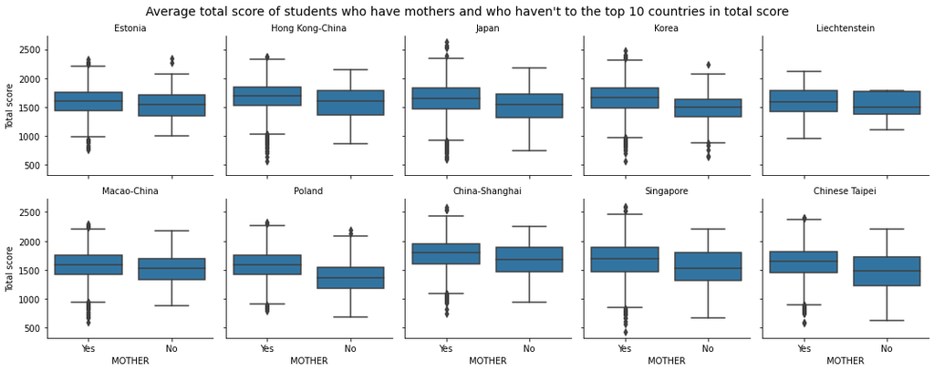

```python
df3 = df2[["MOTHER","FATHER","SUM_SUB","CNT"]].dropna()
MOM = df3[df3["CNT"].isin(top.index)]

g1 = sb.FacetGrid(MOM, col ="CNT",col_wrap=5,size = 3);
g1.map(sb.boxplot, "MOTHER","SUM_SUB")
g1.set_titles(col_template = '{col_name}')
g1.axes[0].set_ylabel("Total score")
g1.axes[5].set_ylabel("Total score")
plt.subplots_adjust(top=0.9)
g1.fig.suptitle("Average total score of students who have mothers and who haven't to the top 10 countries in total score",fontsize = 14)
```

## Father at home vs total student score by the country.

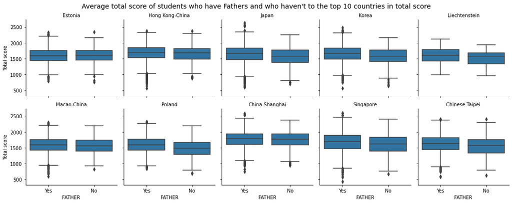

```python
DAD = df3[df3["CNT"].isin(top.index)]
g2 = sb.FacetGrid(DAD, col ="CNT",col_wrap=5)
g2.map(sb.boxplot, "FATHER","SUM_SUB")
g2.set_titles(col_template = "{col_name}")
g2.axes[0].set_ylabel("Total score")
g2.axes[5].set_ylabel("Total score")
plt.tight_layout()

plt.subplots_adjust(top=0.9)
g2.fig.suptitle("Average total score of students who have Fathers and who haven't to the top 10 countries in total score",fontsize = 14)
```

## Is the studant Troublesome vs Father at home and mother at home

> This one was cool to mention, The difference We can see is that the students became more toublesome after the absence of both parents at home.

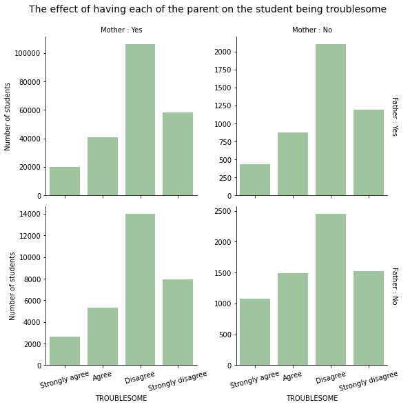

```python
df2['TROUBLESOME']=df2['TROUBLESOME'].astype(CategoricalDtype(categories=['Strongly agree','Agree','Disagree','Strongly disagree']))

df4 = df2[["TROUBLESOME", "MOTHER", "FATHER"]].dropna()
g4= sb.FacetGrid(df4, col= "MOTHER",row = "FATHER",sharey= False, margin_titles=True,size =4,hue_kws={"color":"green"})
g4.map(sb.countplot, "TROUBLESOME",alpha=.4).add_legend()
for ax in g4.axes.flat:
    plt.setp(ax.texts, text="")
    plt.setp(ax.get_xticklabels(),rotation = 15)
g4.set_titles(col_template = "Mother : {col_name}", row_template = "Father : {row_name}")
g4.axes[0,0].set_ylabel("Number of students")
g4.axes[1,0].set_ylabel("Number of students")
plt.subplots_adjust(top=0.9)
g4.fig.suptitle("The effect of having each of the parent on the student being troublesome",fontsize = 14)
```